# Challenge 3 R Notebook

Eagle Xuhui Ying

11/8/2022

## Library

```r
options(scipen = 999) # turns off scientific notation
library(tidymodels)
library(tidyverse)
library(janitor)
library(vip)
library(skimr)
```

## DATA

import data

```r
boston <- read_csv("boston_train.csv") %>% clean_names()
kaggle <- read_csv("boston_holdout.csv") %>% clean_names()
zips   <- read_csv("zips.csv") %>% clean_names()

boston %>% skim()
```

Data summary

| Name | Piped data |
| --- | --- |
| Number of rows | 9959 |
| Number of columns | 33 |
| _______________________ |  |
| Column type frequency: |  |
| character | 15 |
| numeric | 18 |
| ________________________ |  |
| Group variables | None |

**Variable type: character**

| skim_variable | n_missing | complete_rate | min | max | empty | n_unique | whitespace |
| --- | --- | --- | --- | --- | --- | --- | --- |
| own_occ | 0 | 1 | 1 | 1 | 0 | 2 | 0 |
| structure_class | 0 | 1 | 1 | 1 | 0 | 1 | 0 |
| r_bldg_styl | 0 | 1 | 2 | 2 | 0 | 16 | 0 |
| r_roof_typ | 0 | 1 | 1 | 1 | 0 | 7 | 0 |
| r_ext_fin | 0 | 1 | 1 | 1 | 0 | 10 | 0 |
| r_bth_style | 0 | 1 | 1 | 1 | 0 | 4 | 0 |
| r_kitch_style | 0 | 1 | 1 | 1 | 0 | 4 | 0 |
| r_heat_typ | 0 | 1 | 1 | 1 | 0 | 7 | 0 |
| r_ac | 0 | 1 | 1 | 1 | 0 | 3 | 0 |
| r_ext_cnd | 0 | 1 | 1 | 1 | 0 | 5 | 0 |
| r_ovrall_cnd | 0 | 1 | 1 | 1 | 0 | 5 | 0 |
| r_int_cnd | 0 | 1 | 1 | 1 | 0 | 5 | 0 |
| r_int_fin | 0 | 1 | 1 | 1 | 0 | 2 | 0 |
| r_view | 0 | 1 | 1 | 1 | 0 | 5 | 0 |
| city_state | 0 | 1 | 13 | 21 | 0 | 5 | 0 |

**Variable type: numeric**

| skim_variable | n_missing | complete_rate | mean | sd | p0 | p25 | p50 | p75 | p100 | hist |
| --- | --- | --- | --- | --- | --- | --- | --- | --- | --- | --- |
| pid | 0 | 1.00 | 71093.60 | 41011.82 | 10 | 35780.0 | 71180 | 106575 | 142240 | ▇▇▇▇▇ |
| zipcode | 0 | 1.00 | 2131.45 | 3.69 | 2124 | 2131.0 | 2132 | 2132 | 2136 | ▃▁▆▇▆ |
| av_total | 0 | 1.00 | 448563.64 | 147761.17 | 134800 | 347100.0 | 418700 | 510150 | 1097100 | ▂▇▂▁▁ |
| land_sf | 0 | 1.00 | 5936.18 | 2954.01 | 920 | 4319.0 | 5320 | 6756 | 107158 | ▇▁▁▁▁ |
| yr_built | 0 | 1.00 | 1933.40 | 35.28 | 0 | 1910.0 | 1931 | 1955 | 2016 | ▁▁▁▁▇ |
| yr_remod | 347 | 0.97 | 675.71 | 946.59 | 0 | 0.0 | 0 | 1997 | 2016 | ▇▁▁▁▅ |
| living_area | 0 | 1.00 | 1659.00 | 545.95 | 332 | 1300.0 | 1554 | 1914 | 8623 | ▇▂▁▁▁ |
| num_floors | 0 | 1.00 | 1.73 | 0.45 | 1 | 1.5 | 2 | 2 | 3 | ▃▂▇▁▁ |
| r_total_rms | 0 | 1.00 | 7.11 | 1.55 | 3 | 6.0 | 7 | 8 | 17 | ▁▇▂▁▁ |
| r_bdrms | 0 | 1.00 | 3.34 | 0.92 | 0 | 3.0 | 3 | 4 | 9 | ▁▇▃▁▁ |
| r_full_bth | 0 | 1.00 | 1.35 | 0.56 | 1 | 1.0 | 1 | 2 | 6 | ▇▁▁▁▁ |
| r_half_bth | 0 | 1.00 | 0.56 | 0.55 | 0 | 0.0 | 1 | 1 | 10 | ▇▁▁▁▁ |
| r_kitch | 0 | 1.00 | 1.02 | 0.14 | 1 | 1.0 | 1 | 1 | 3 | ▇▁▁▁▁ |
| r_fplace | 0 | 1.00 | 0.60 | 0.62 | 0 | 0.0 | 1 | 1 | 5 | ▇▁▁▁▁ |
| zip | 0 | 1.00 | 2131.45 | 3.69 | 2124 | 2131.0 | 2132 | 2132 | 2136 | ▃▁▆▇▆ |
| population | 0 | 1.00 | 34871.56 | 6299.30 | 28488 | 29826.0 | 35401 | 36314 | 47783 | ▇▂▆▁▃ |
| pop_density | 0 | 1.00 | 11368.99 | 3293.58 | 6207 | 10618.0 | 11505 | 13251 | 15913 | ▆▁▆▇▃ |
| median_income | 0 | 1.00 | 65984.07 | 9749.72 | 48841 | 58890.0 | 66735 | 75446 | 75730 | ▃▅▁▃▇ |

## Histogram Target

The first plot shows us that the data are right-skewed; there are more inexpensive houses than expensive ones. When modeling this type of outcome, a strong argument can be made that the price should be log-transformed. The advantages of this type of transformation are that no houses would be predicted with negative sale prices and that errors in predicting expensive houses will not have an undue influence on the model. you can deal with this in the recipe

```r
median(boston$av_total)
```

```
## [1] 418700
```

```r
mean(boston$av_total)
```

```
## [1] 448563.6
```

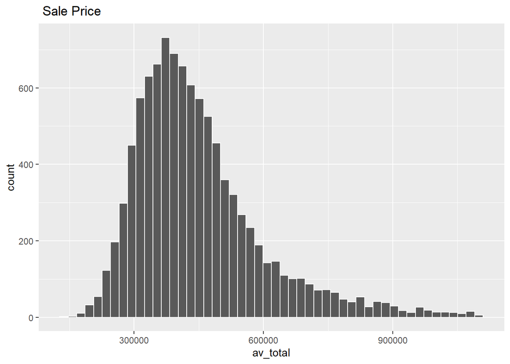

```r
ggplot(boston, aes(x = av_total)) +
  geom_histogram(bins = 50, col= "white") +
  labs(title=" Sale Price")
```

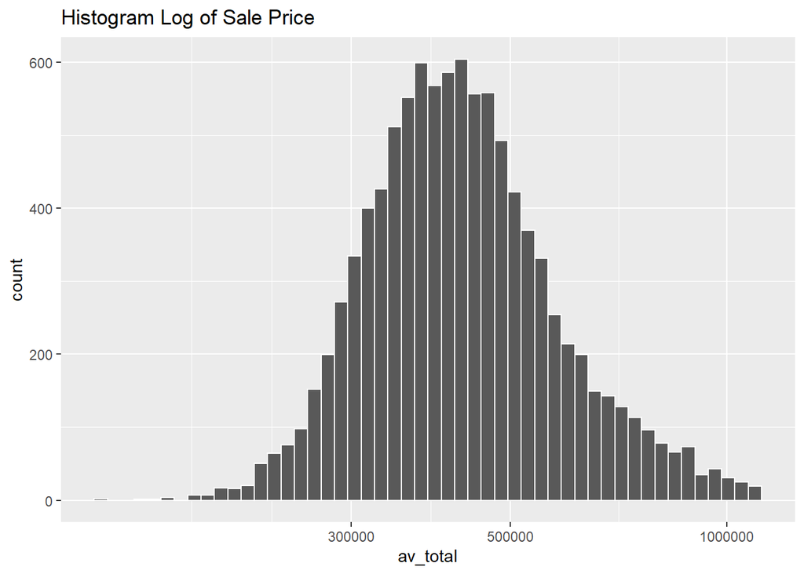

```r
ggplot(boston, aes(x = av_total)) +
  geom_histogram(bins = 50, col= "white") +
  scale_x_log10() +
  labs(title="Histogram Log of Sale Price")
```

## Explore numerics

numeric variables: pid, land_sf, yr_built, yr_remod, living_area, num_floors, r_total_rms, r_bdrms, r_full_bth, r_half_bth, r_kitch, r_fplace, population, pop_density, median_income

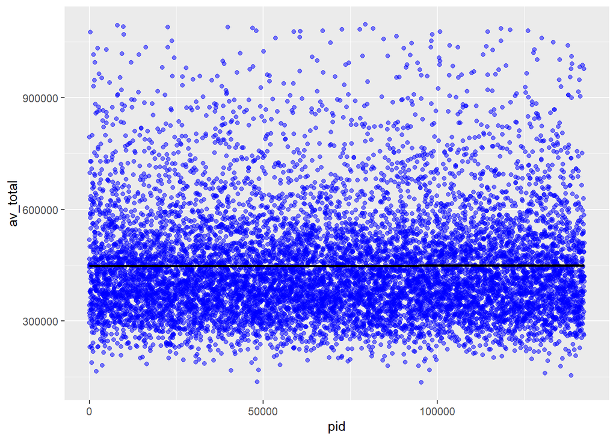

```r
ggplot(data = boston[!is.na(boston$av_total),], aes(x=pid, y=av_total))+
  geom_point(col='blue',alpha=0.5) + geom_smooth(method = 'lm', se=FALSE, color='black', aes(group=1))
```

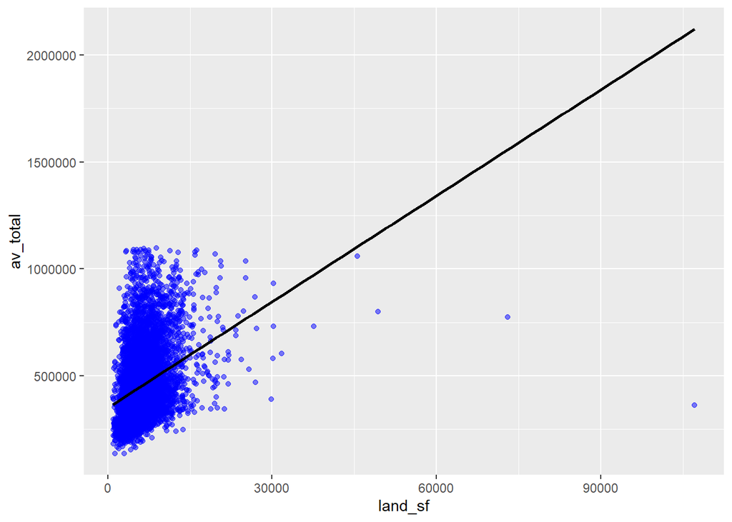

```r
ggplot(data = boston[!is.na(boston$av_total),], aes(x=land_sf, y=av_total))+
  geom_point(col='blue',alpha=0.5) + geom_smooth(method = 'lm', se=FALSE, color='black', aes(group=1))
```

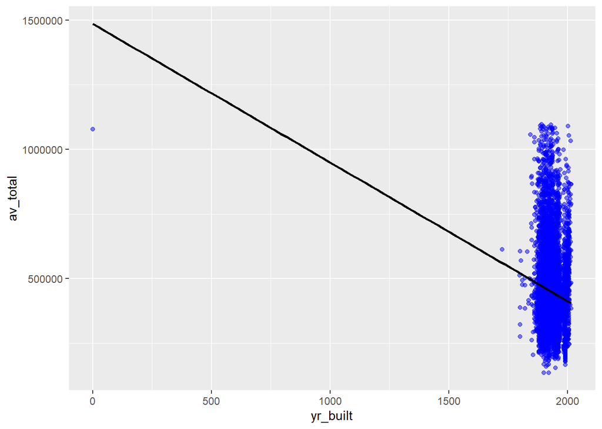

```r
ggplot(data = boston[!is.na(boston$av_total),], aes(x=yr_built, y=av_total))+
  geom_point(col='blue',alpha=0.5) + geom_smooth(method = 'lm', se=FALSE, color='black', aes(group=1))
```

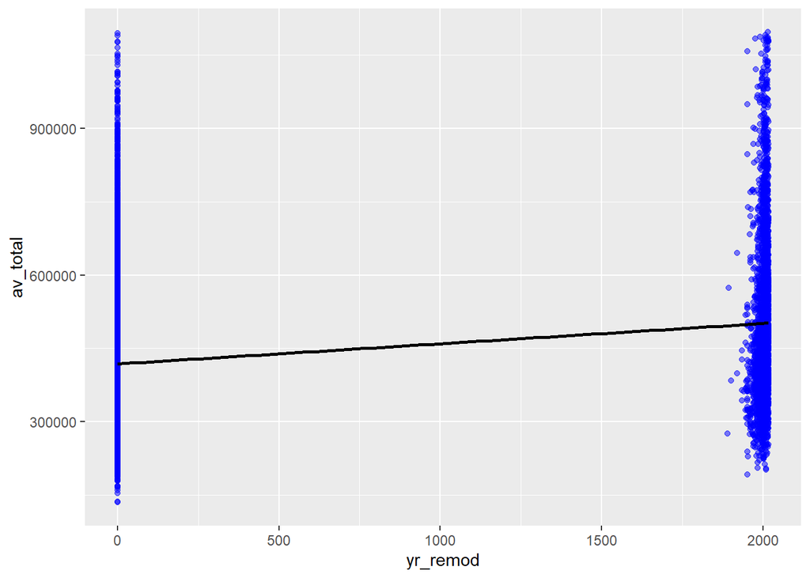

```r
ggplot(data = boston[!is.na(boston$av_total),], aes(x=yr_remod, y=av_total))+
  geom_point(col='blue',alpha=0.5) + geom_smooth(method = 'lm', se=FALSE, color='black', aes(group=1))
```

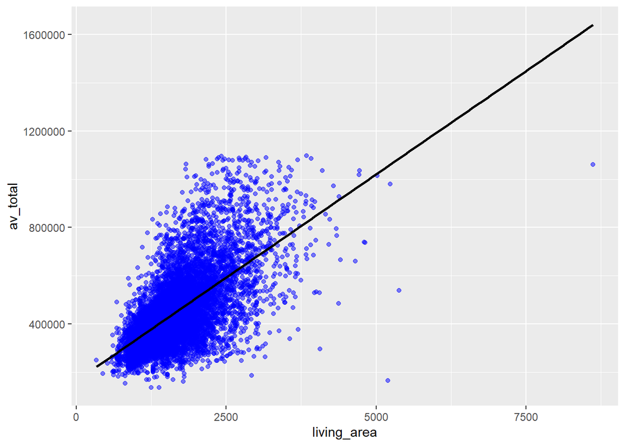

```r
ggplot(data = boston[!is.na(boston$av_total),], aes(x=living_area, y=av_total))+
  geom_point(col='blue',alpha=0.5) + geom_smooth(method = 'lm', se=FALSE, color='black', aes(group=1))
```

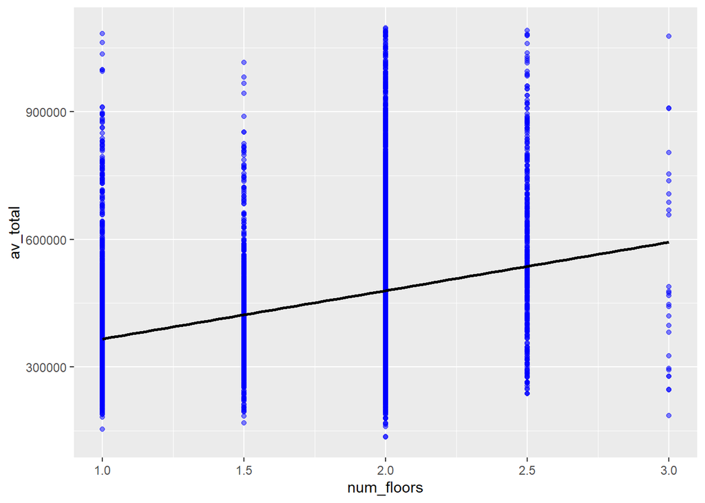

```r
ggplot(data = boston[!is.na(boston$av_total),], aes(x=num_floors, y=av_total))+
  geom_point(col='blue',alpha=0.5) + geom_smooth(method = 'lm', se=FALSE, color='black', aes(group=1))
```

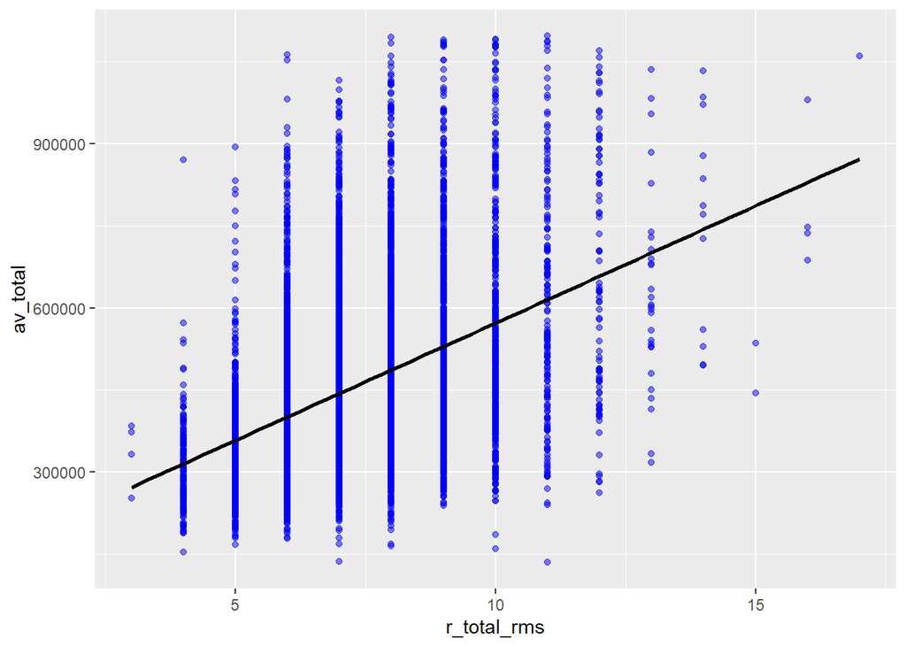

```r
ggplot(data = boston[!is.na(boston$av_total),], aes(x=r_total_rms, y=av_total))+
  geom_point(col='blue',alpha=0.5) + geom_smooth(method = 'lm', se=FALSE, color='black', aes(group=1))
```

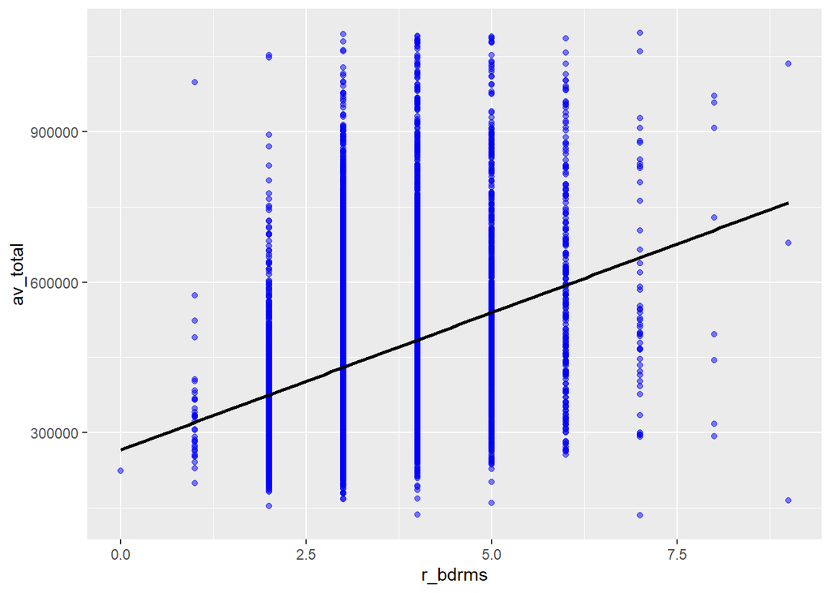

```r
ggplot(data = boston[!is.na(boston$av_total),], aes(x=r_bdrms, y=av_total))+
  geom_point(col='blue',alpha=0.5) + geom_smooth(method = 'lm', se=FALSE, color='black', aes(group=1))
```

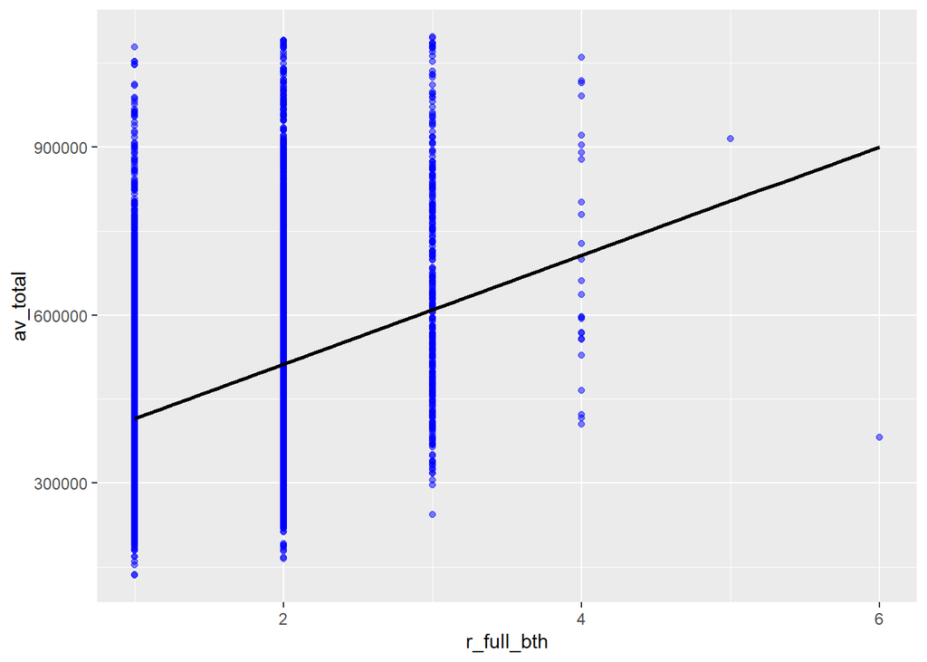

```r
ggplot(data = boston[!is.na(boston$av_total),], aes(x=r_full_bth, y=av_total))+
  geom_point(col='blue',alpha=0.5) + geom_smooth(method = 'lm', se=FALSE, color='black', aes(group=1))
```

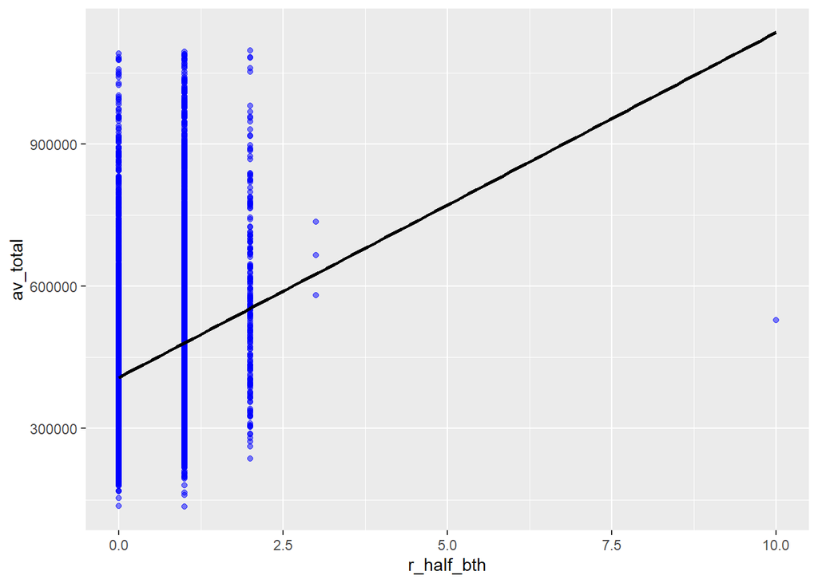

```r
ggplot(data = boston[!is.na(boston$av_total),], aes(x=r_half_bth, y=av_total))+
  geom_point(col='blue',alpha=0.5) + geom_smooth(method = 'lm', se=FALSE, color='black', aes(group=1))
```

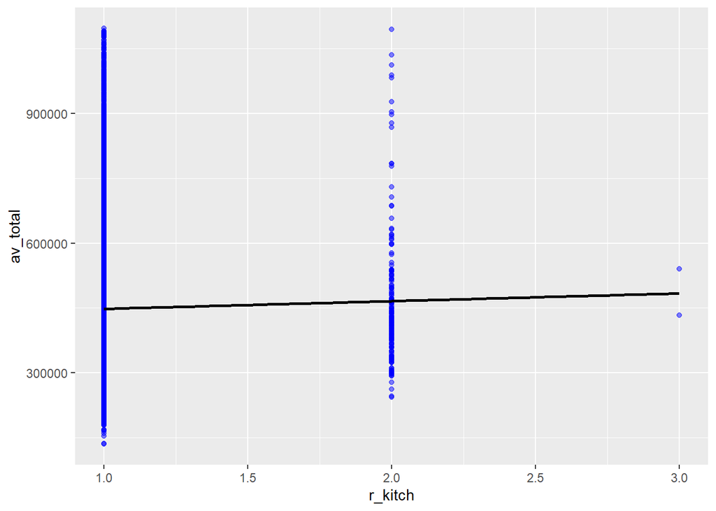

```r
ggplot(data = boston[!is.na(boston$av_total),], aes(x=r_kitch, y=av_total))+
  geom_point(col='blue',alpha=0.5) + geom_smooth(method = 'lm', se=FALSE, color='black', aes(group=1))
```

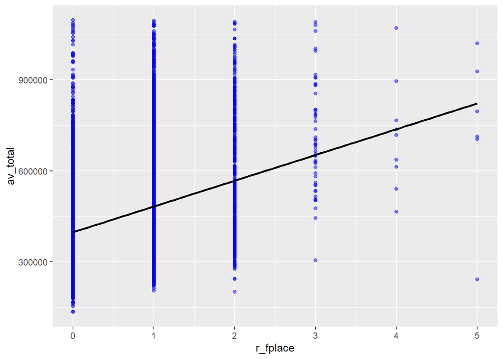

```r
ggplot(data = boston[!is.na(boston$av_total),], aes(x=r_fplace, y=av_total))+
  geom_point(col='blue',alpha=0.5) + geom_smooth(method = 'lm', se=FALSE, color='black', aes(group=1))
```

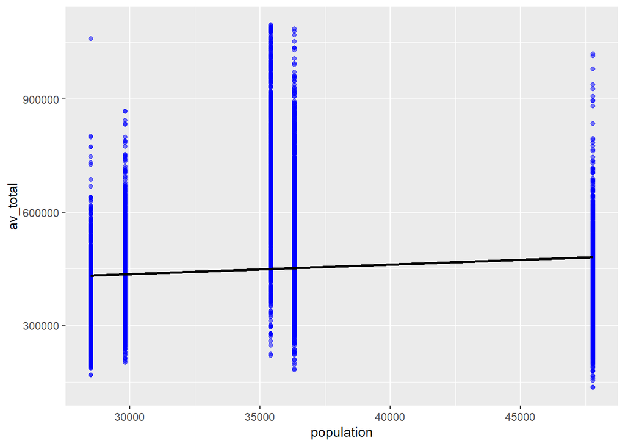

```r
ggplot(data = boston[!is.na(boston$av_total),], aes(x=population, y=av_total))+
  geom_point(col='blue',alpha=0.5) + geom_smooth(method = 'lm', se=FALSE, color='black', aes(group=1))
```

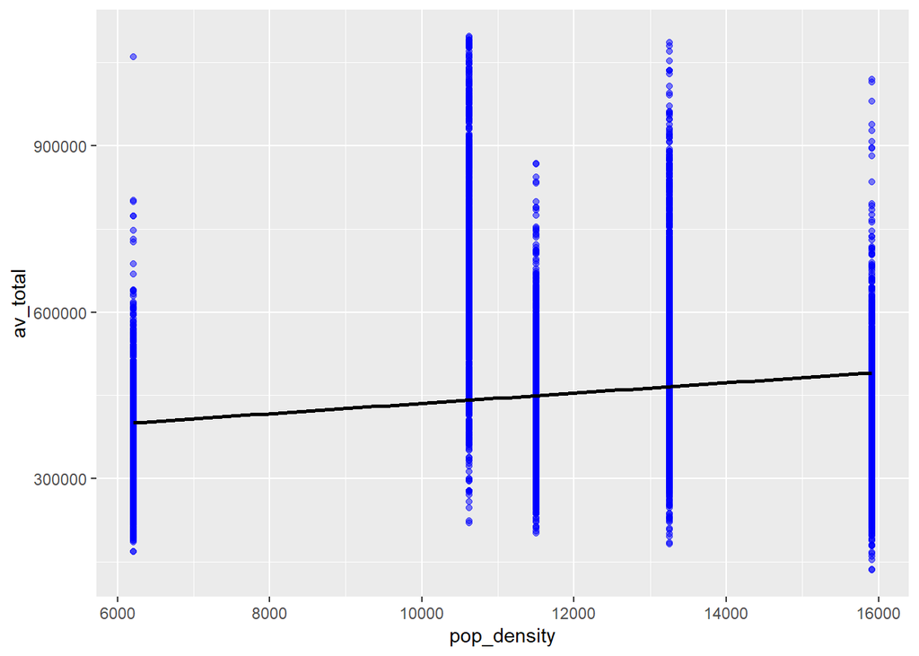

```r
ggplot(data = boston[!is.na(boston$av_total),], aes(x=pop_density, y=av_total))+
  geom_point(col='blue',alpha=0.5) + geom_smooth(method = 'lm', se=FALSE, color='black', aes(group=1))
```

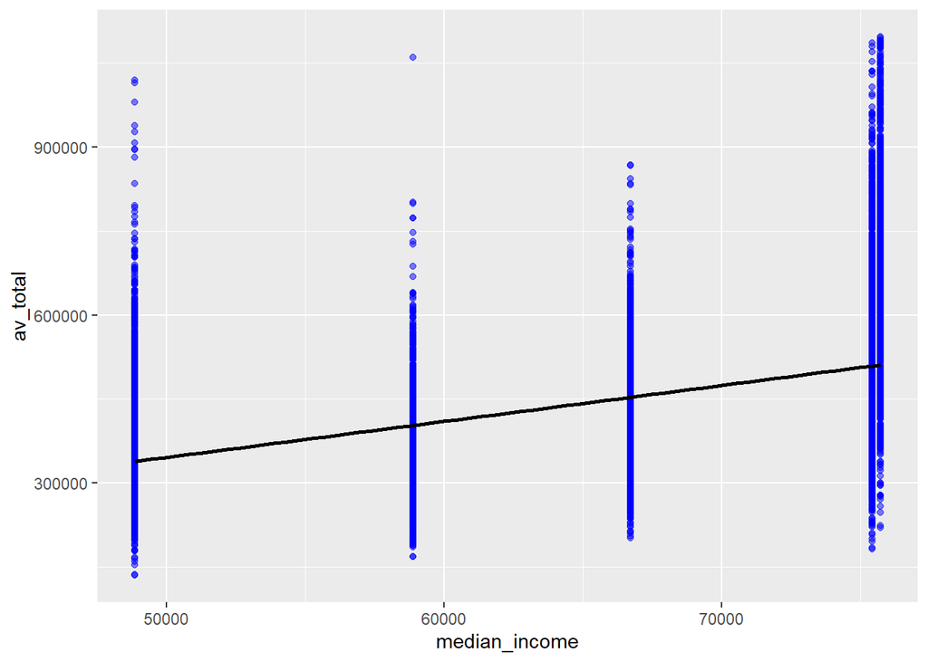

```r
ggplot(data = boston[!is.na(boston$av_total),], aes(x=median_income, y=av_total))+
  geom_point(col='blue',alpha=0.5) + geom_smooth(method = 'lm', se=FALSE, color='black', aes(group=1))
```

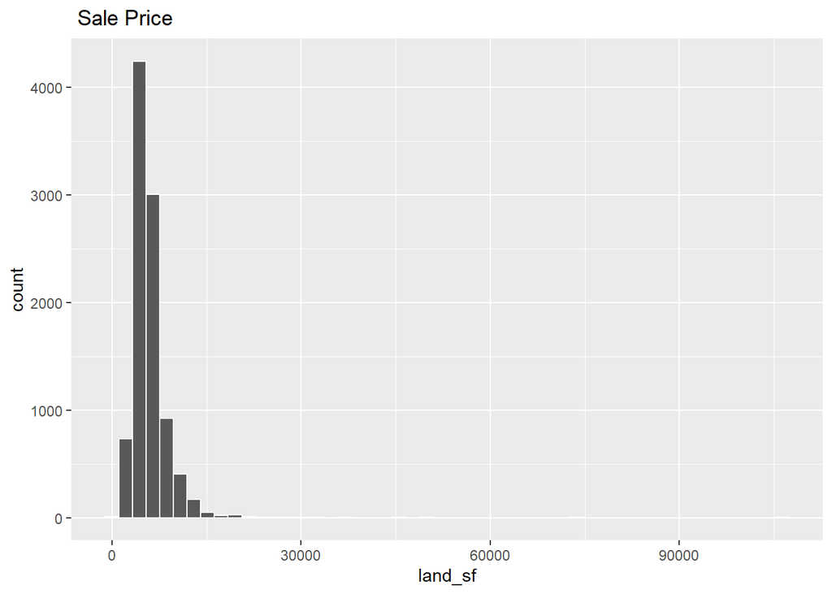

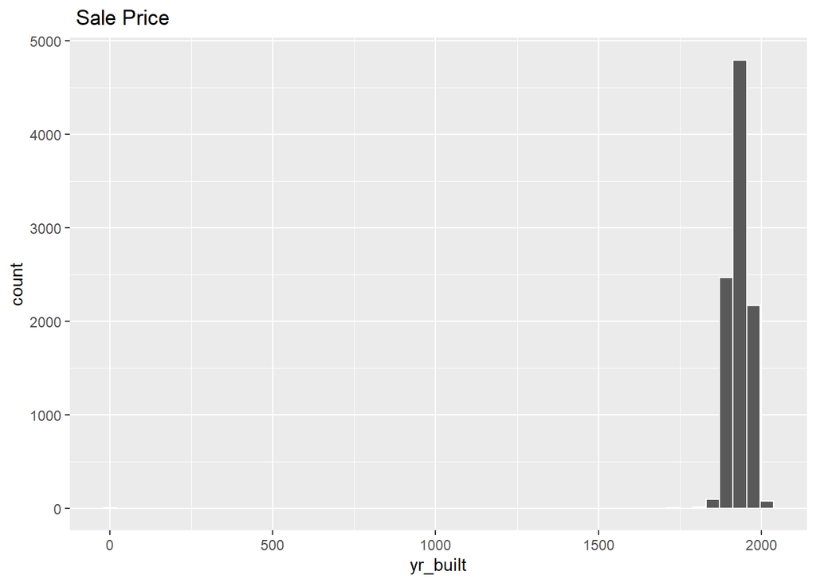

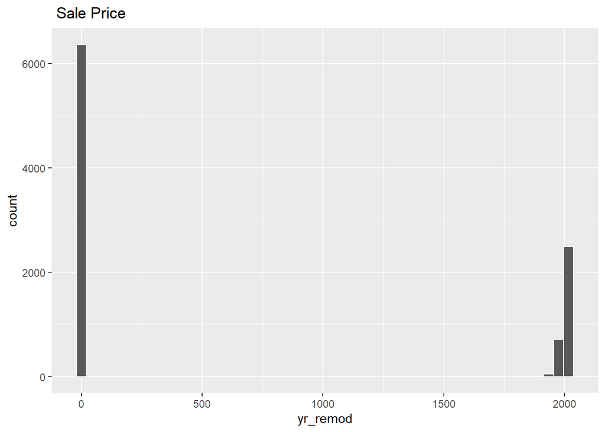

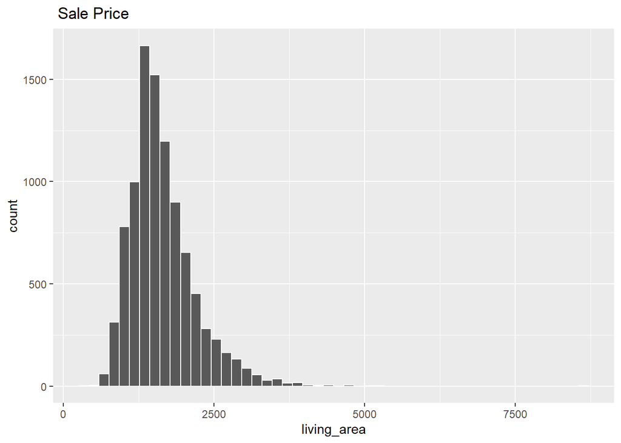

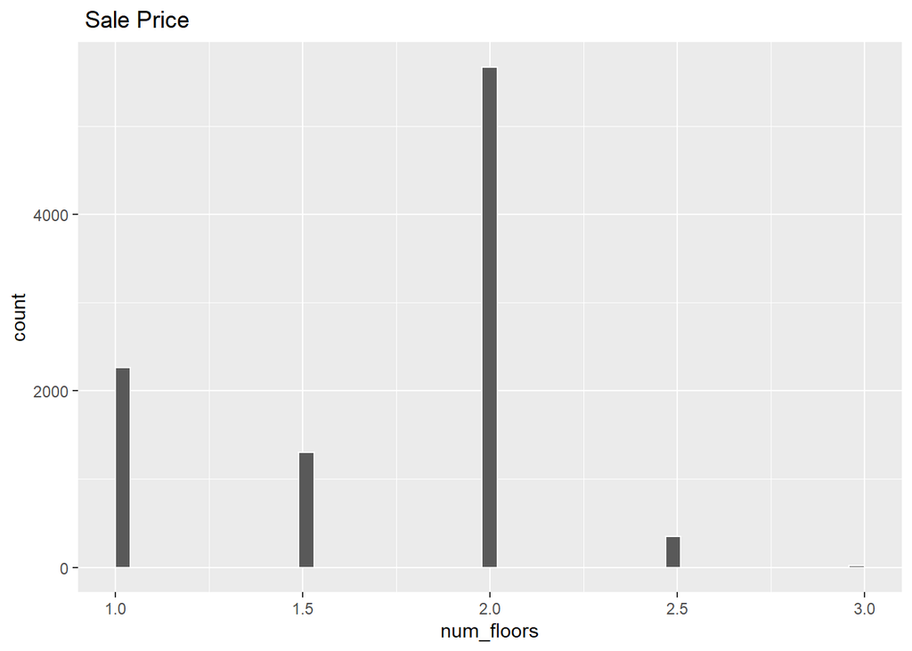

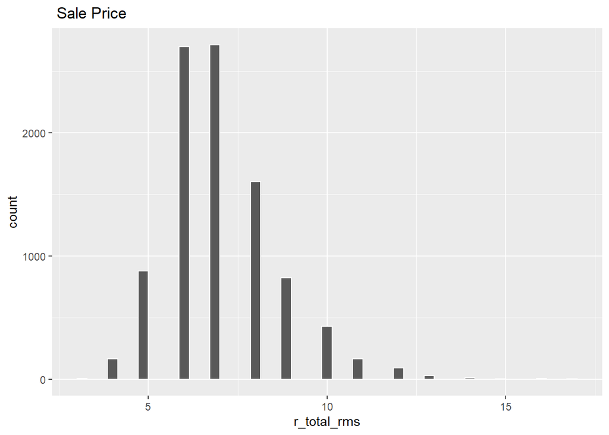

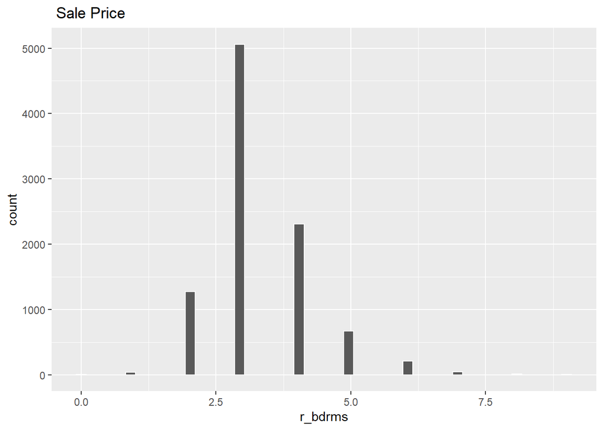

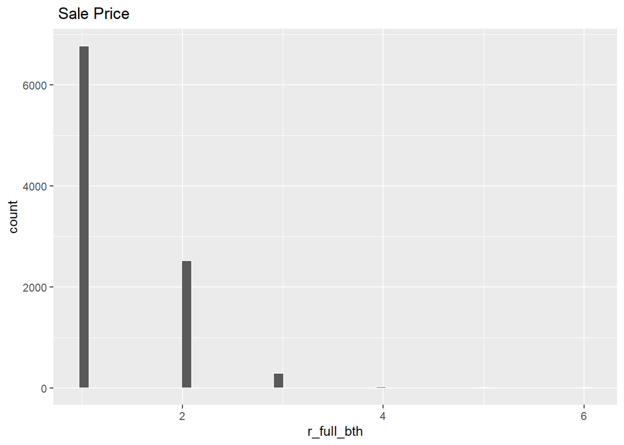

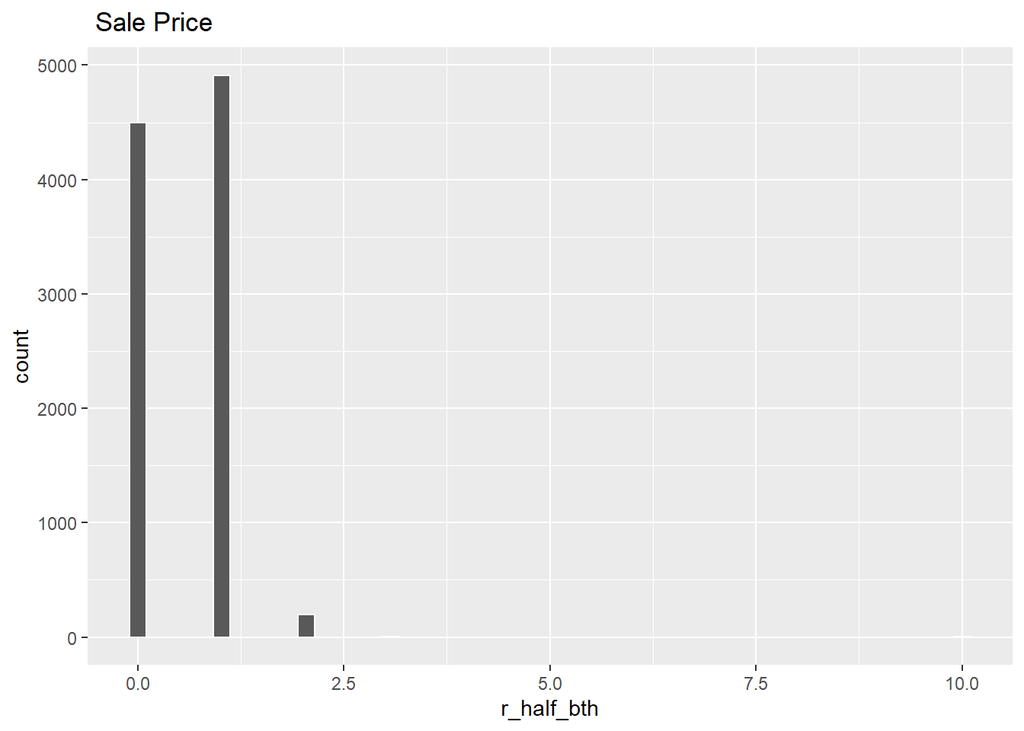

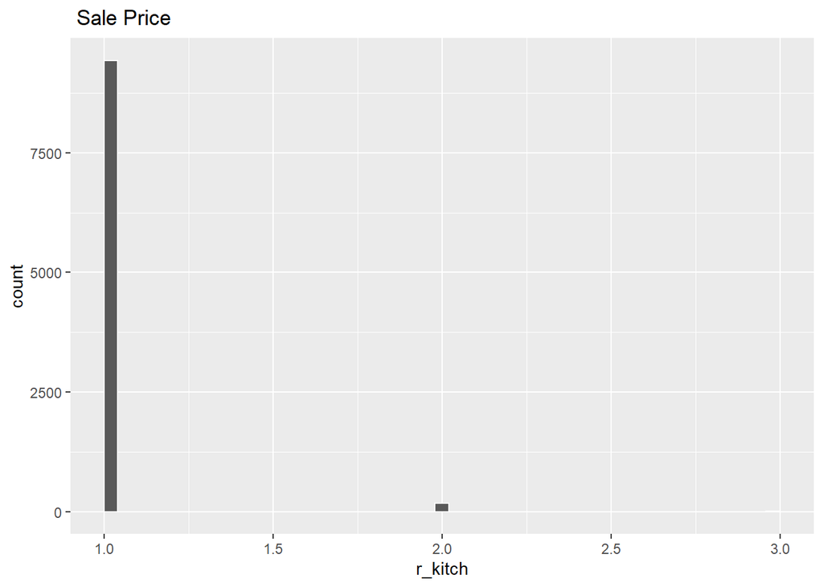

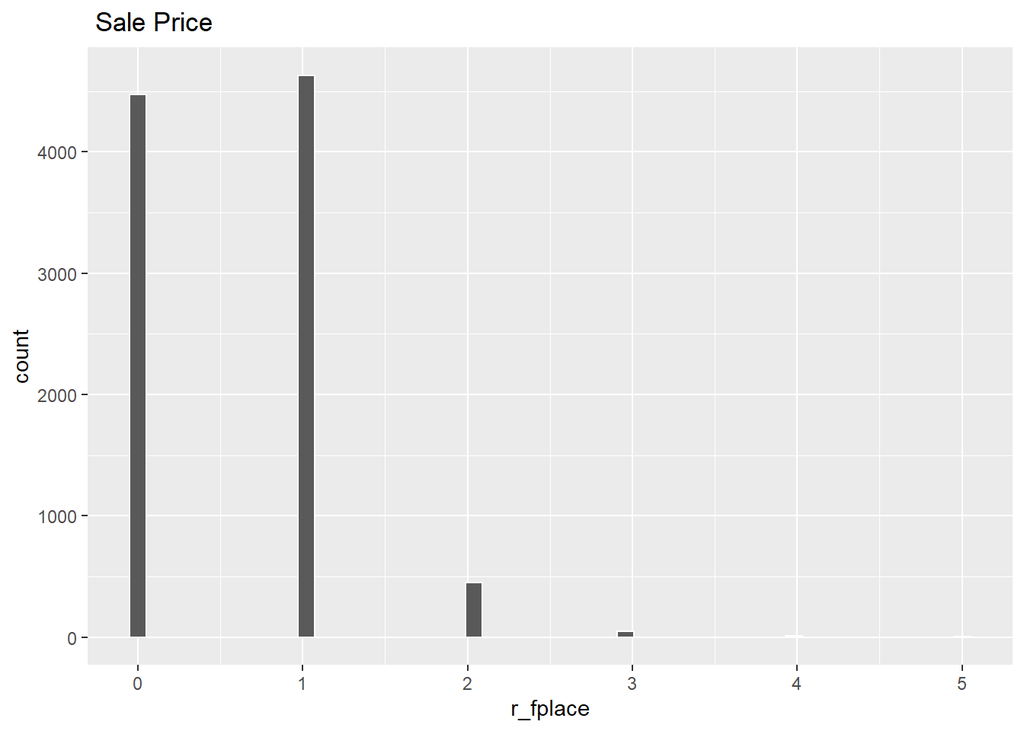

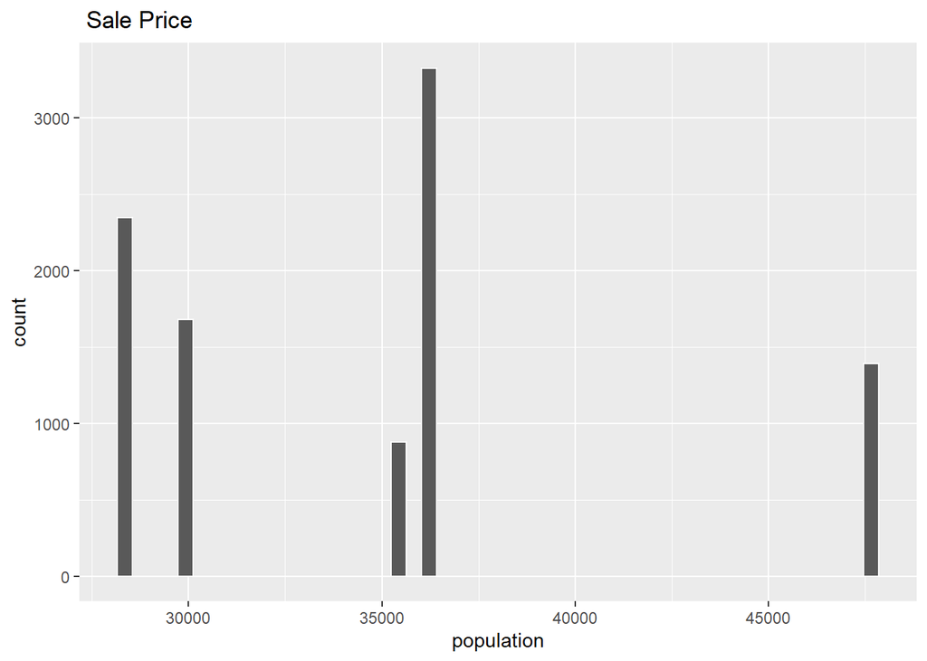

[2 more figures not shown]

```r
histogram <- function(m){
  options(scipen = 999)
  boston %>%
  na.omit() %>%
  ggplot(aes(x = !!as.name(m))) +
  geom_histogram(bins = 50, col= "white") +
  labs(title=" Sale Price")
}

numerics <- c('land_sf', 'yr_built', 'yr_remod', 'living_area', 'num_floors', 'r_total_rms', 'r_bdrms', 'r_full_bth', 'r_half_bth', 'r_kitch', 'r_fplace', 'population', 'pop_density', 'median_income')

for (c in numerics){
    print(histogram(c))
}
```

## Explore character variables

categorical variables: zipcode, own_occ, structure_class, r_bldg_styl, r_roof_typ, r_ext_fin, r_bth_style, r_kitch_style, r_heat_typ, r_ac, r_ext_cnd, r_ovrall_cnd, r_int_cnd, r_int_fin, r_view, zip, city_state

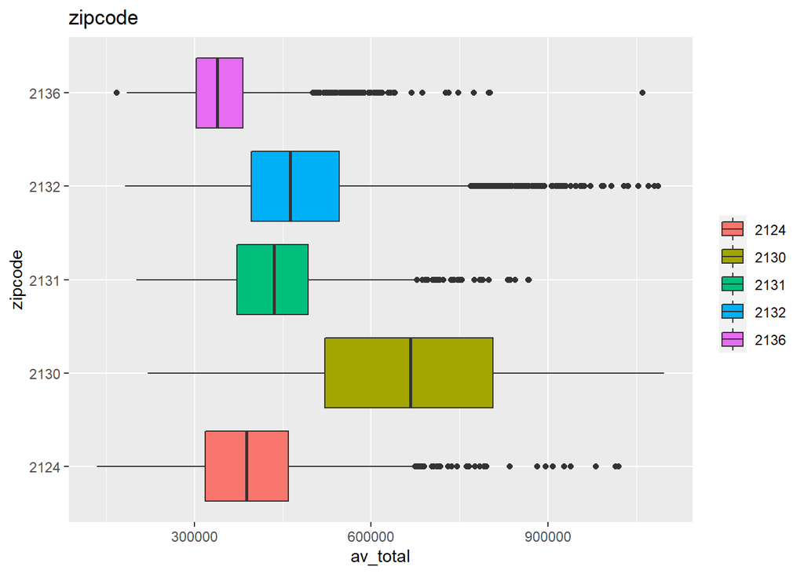

```r
ggplot(boston, aes(x=av_total, y=as.factor(zipcode), fill=as.factor(zipcode))) +
  geom_boxplot() + labs(title = 'zipcode', x = 'av_total', y = 'zipcode') + theme(legend.title = element_blank())
```

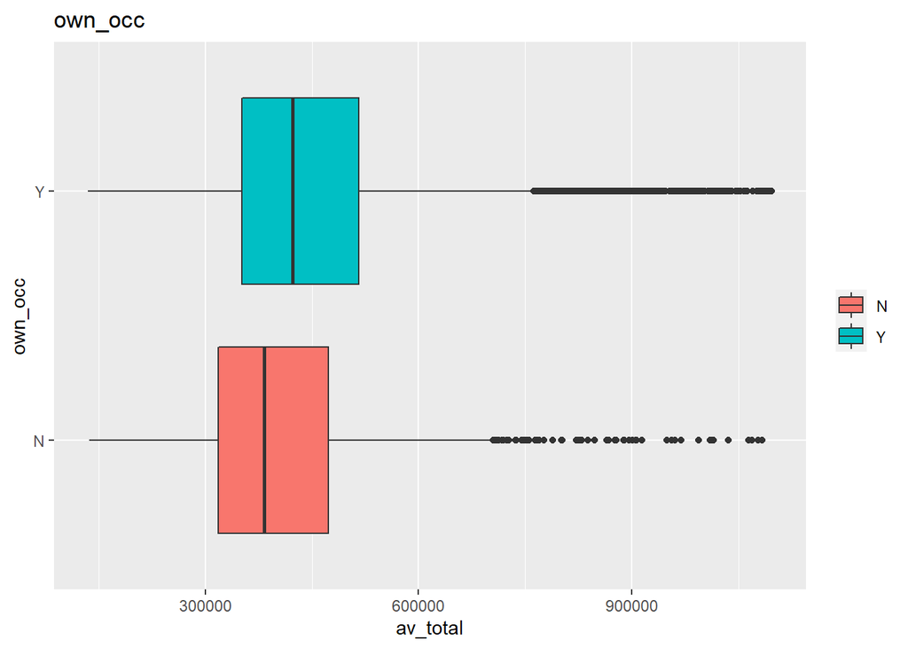

```r
ggplot(boston, aes(x=av_total, y=as.factor(own_occ), fill=as.factor(own_occ))) +
  geom_boxplot() + labs(title = 'own_occ', x = 'av_total', y = 'own_occ') + theme(legend.title = element_blank())
```

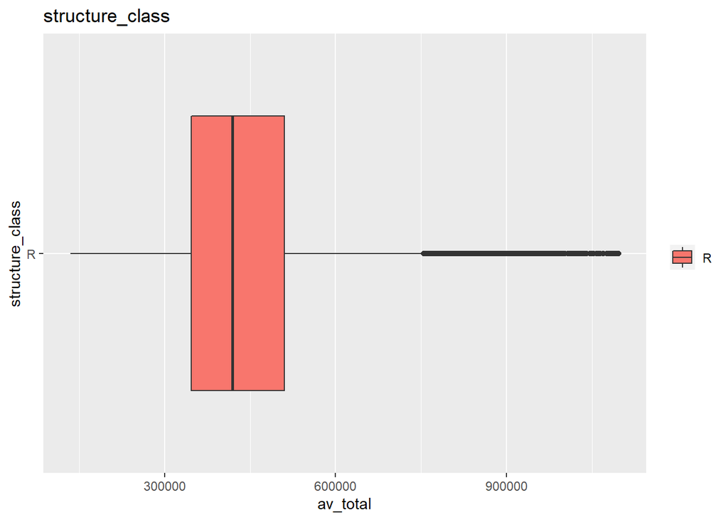

```r
ggplot(boston, aes(x=av_total, y=as.factor(structure_class), fill=as.factor(structure_class))) +
  geom_boxplot() + labs(title = 'structure_class', x = 'av_total', y = 'structure_class') + theme(legend.title = element_blank())
```